# Summary of DCF diadroumus species data for DIASPARA WP 2.1

Author

Viktor Thunell

Published

April 9, 2025

## Background

DIASPARA will make recommendations to enhance the DCF and Regional Workplans. DIASPARA aims to better align data needs and data collection, as such, it will contribute to the objectives of the DCF and the CFP, and will also bring valuable insights for the future Regional Workplans.

As part of this work, Workpackage 2 will create an inventory of available and potentially available data on Atlantic salmon and European eel LHTs (T2.1.1) and identify gaps in the current DCF and make recommendations for improvements in data collection based on assessment model needs identified in WP4 (T2.1.2)

This script summarizes information in the DCF Annual reports on collected data for diadromous species.

The summary can be used to * Compare data availability with future data needs to implement key variation in LHTs in SSAM.

## Load libraries

```r
# Load libraries, install if needed
pkgs <- c("tidyverse", "tidylog", "devtools","viridis", "patchwork", "rvest", "readxl","httr","janitor")

if(length(setdiff(pkgs,rownames(installed.packages()))) > 0){

    install.packages(setdiff(pkgs, rownames(installed.packages())), dependencies = T)

  }

invisible(lapply(pkgs, library, character.only = T))

options(ggplot2.continuous.colour = "viridis")
theme_set(theme_grey())

devtools::source_url("https://raw.githubusercontent.com/VThunell/diasp-lht/main/R/functions/map-plot.R")

# Set path
home <- here::here()
```

## Download files from DCF annual reports hompage

https://dcf.ec.europa.eu/wps-and-ars/annual-reports_en

Using inspiration from: https://rvest.tidyverse.org/articles/rvest.html https://webscraping-tures.github.io/files.html#downloading-files

```r
# Reading the HTML page with read_html():

# DCF.Ann.Reps <- read_html("https://dcf.ec.europa.eu/wps-and-ars/annual-reports_en")
#
# DCF.Ann.Reps.links <- DCF.Ann.Reps %>%
#   html_nodes("a") %>% #https://rvest.tidyverse.org/articles/rvest.html
#   html_attr(name="href") %>%
#   as_tibble() %>%
#   filter(str_detect(value, '_tables')) %>%
#   #filter(str_detect(value, '_tables|_text')) %>% # the link names in the html are not correctly separeted between table and text so I must dowload both and filter out pdfs from xls:s later
#   pull(value)
#
# #To get content type from link
# #GET(DCF.Ann.Reps.links[1])
#
# f.download.DCF <- function(link)  {
#
#   download.file(link, destfile = paste0("/Users/vitl0001/Documents/Projects/DIASPARA/Incoming other files/DCF Annual Reports/", basename(link),".xlsx"))
#
#   }
#
# possdnld = possibly(.f = f.download.DCF, otherwise = NULL) #try download and store file otherwise return NULL
#
# map(DCF.Ann.Reps.links, ~possdnld(.x) ) %>%
#   map(\(x) f.download.DCF)

# DCF.Ann.Reps.links %>%
#   map(\(x) download.file(x, destfile = paste0("/Users/vitl0001/Documents/Projects/DIASPARA/Incoming other files/DCF Annual Reports/", str_replace_all(x, regex("\\W+"), "_"),
                           #                    ".xlsx")))
```

## Import and combine data from tables and summarise not imorted reports

The not imported files are either not tables (pdfs) or table 2.2 does not exist. The format chnaged between 2021 and 2022, the corresponding sheet is “Table1C Sampling intensity” for years pre 2022.

### Path for importing files

```r
path <- paste0("/Users/vitl0001/Documents/Projects/DIASPARA/Incoming other files/DCF Annual Reports/")
filepaths <- list.files(path, full.names=TRUE)
#filepaths <- filepaths[!grepl("^~\\$", filepaths)] # FIX REGEX?? ensure any temporrary files are excluded

# 100 files downloaded out of 103 links
# length(filepaths)
# length(DCF.Ann.Reps.links)
```

### Import from new table format, i.e. post 2022

#### Table 2.2. Planning of sampling for biological variables

```r
f.DCF.bind22 <- function(file)  {

  sheetnum = which(str_detect(excel_sheets(file),"2.2"))

  read_excel(file, sheet = sheetnum, skip = 1) %>% # skip first row
    filter(Species %in% c("Salmo salar", "Anguilla anguilla", "Salmo trutta")) # this also removes the row under the headers

  }

possxls22 = possibly(.f = f.DCF.bind22, otherwise = NULL) # NULL if table 2.2. doesnt exist

DCF.tables.22 = map(filepaths, ~possxls22(.x) ) %>%
  setNames(basename(filepaths))

diadrom.DCF.22 <- DCF.tables.22 %>%
  keep(~!is.null(.x) ) %>%
  keep(~nrow(.x) > 0) %>%
  map(~mutate_if(.x, is.numeric, as.character)) %>% # make all numeric as types  differ between the sheets
  list_rbind()
```

#### Table 2.3. Diadromous species data collection in freshwater

```r
f_DCF_bind23 <- function(file)  {

  sheetnum = which(str_detect(excel_sheets(file),"2.3"))

  read_excel(file, sheet = sheetnum, skip = 1) %>% # skip first row
       slice(-1) # remove the row under the headers whithout data

  }

possxls.23 <- possibly(.f = f_DCF_bind23, otherwise = NULL) # NULL if table 2.3 does not exist
DCF.tables.23 <- map(filepaths, ~possxls.23(.x) ) %>%
  setNames(basename(filepaths))

diadrom.DCF.23 <- DCF.tables.23 %>%
  keep(~!is.null(.x) ) %>%
  keep(~nrow(.x) > 0) %>%
  map(~mutate_if(.x, is.numeric, as.character)) %>% # make all numeric as types  differ between the sheets
  list_rbind()
```

### Import from old table format, i.e. years pre 2022.

#### Table 1C: Sampling intensity for biological variables

```r
f_DCF_bind1C <- function(file)  {

  sheetnum = which(str_detect(excel_sheets(file),"1C"))

  read_excel(file, sheet = sheetnum, skip = 3) %>% # skip 3 rows
    filter(Species %in% c("Salmo salar", "Anguilla anguilla", "Salmo trutta"))

  }

possxls.1C = possibly(.f = f_DCF_bind1C, otherwise = NULL) # NULL if table 2.2. doesnt exist
DCF.tables.1C = map(filepaths, ~possxls.1C(.x) ) %>%
  setNames(basename(filepaths))

diadrom.DCF.1C <- DCF.tables.1C %>%
  keep(~!is.null(.x) ) %>%
  keep(~nrow(.x) > 0) %>%
  map(~mutate_if(.x, is.numeric, as.character)) %>% # make all numeric as types  differ between the sheets
  list_rbind()
```

#### Table1E Anadromous catadromous for years pre 2022.

```r
f_DCF_bind1E <- function(file)  {

  sheetnum = which(str_detect(excel_sheets(file),"1E"))

  read_excel(file, sheet = sheetnum, skip = 3)# %>% # skip 3 rows

  }

possxls.1E <- possibly(.f = f_DCF_bind1E, otherwise = NULL) # NULL if table 2.2. doesnt exist
DCF.tables.1E <- map(filepaths, ~possxls.1E(.x) ) %>%
  setNames(basename(filepaths))

diadrom.DCF.1E <- DCF.tables.1E %>%
  keep(~!is.null(.x) ) %>%
  keep(~nrow(.x) > 0) %>%
  map(~mutate_if(.x, is.numeric, as.character)) %>% # make all numeric as types  differ between the sheets
  list_rbind()
```

## Which reports are not imported?

```r
no.import22 <- DCF.tables.22 %>% # Where there's no table 2.2.
  keep(~is.null(.x) ) %>%
  names()
no.import23 <- DCF.tables.23 %>% # Where there's no table 2.3.
  keep(~is.null(.x) ) %>%
  names()
no.import1C <- DCF.tables.1C %>% # Where there's no table 1C.
  keep(~is.null(.x) ) %>%
  names()
no.import1E <- DCF.tables.1E %>% # Where there's no table 1C.
  keep(~is.null(.x) ) %>%
  names()

# the NULL files where there is no table 2.2 or 1C
no.import22 %>%
  keep(~.x %in% no.import1C) %>%
  str_subset(fixed("~$"), negate = TRUE) # subset the reporst that are not open files (which creates a copy of the file with "~$" in the name)
```

```
[1] "austria_annual_report_2023_tables.xlsx"
[2] "czech_republic_annual_report_2022_tables_2023-05-31.xlsx"
[3] "czech-republic_annual_report_2023_tables.xlsx"
[4] "hungary_annual_report_2021_tables.xlsx"
[5] "hungary_annual_report_2022_tables_2023-09-25_v3.xlsx"
[6] "romania_annual_report_2020_tables.xlsx"
[7] "romania_annual_report_2021_tables.xlsx"
[8] "slovakia_annual_report_2022-2027_tables_slovakia-ar-2022-v3.xlsx"
[9] "slovakia_annual_report_2023_tables.xlsx"
```

```r
# the NULL files where there is no table or 2.3 or 1E
no.import23 %>%
  keep(~.x %in% no.import1E) %>%
  str_subset(fixed("~$"), negate = TRUE) # subset the reporst that are not open files
```

```
 [1] "austria_annual_report_2023_tables.xlsx"
 [2] "bulgaria_annual_report_2022_tables_2023-06-21.xlsx"
 [3] "bulgaria_annual_report_2023_tables.xlsx"
 [4] "cyprus_annual_report_2022_tables_2023-05-31.xlsx"
 [5] "cyprus_annual_report_2023_tables.xlsx"
 [6] "hungary_annual_report_2021_tables.xlsx"
 [7] "hungary_annual_report_2022_tables_2023-09-25_v3.xlsx"
 [8] "malta_annual_report_2022_tables_2023-06-21.xlsx"
 [9] "romania_annual_report_2020_tables.xlsx"
[10] "romania_annual_report_2021_tables.xlsx"
[11] "slovakia_annual_report_2022-2027_tables_slovakia-ar-2022-v3.xlsx"
[12] "slovakia_annual_report_2023_tables.xlsx"
```

```r
# I guess these are reports which countries that dont have diadromous fish managed through the CFP??
```

## Plot

### Plot sheets 2.2 and 1C

```r
# What are the biological variables in the two sheets
c(diadrom.DCF.1C$Variables,diadrom.DCF.22$`Biological variable`) %>%
  unique()
```

```
 [1] "Length"          "Age"             "Weight"          "Sex ratio"
 [5] "Sexual maturity" "length"          "sex"             "weight"
 [9] "age"             "maturity"        "sex ratio"       "sexual maturity"
[13] "lenght"          "Maturity"        "Sex"             "NA"
[17] "Fecundity"
```

```
rename: renamed 4 variables (country, year, biol.var, ach.n.ind)
select: dropped 17 variables (Region, RFMO/RFO/IO, Area, Data collection requested by end user, Observation type, …)
rename: renamed 4 variables (country, year, biol.var, ach.n.ind)
select: dropped 15 variables (MS partcipating in sampling, Region, RFMO/RFO/IO, Area / Stock, Data sources, …)
mutate: changed 195 values (62%) of 'biol.var' (6 new NAs)
mutate: converted 'ach.n.ind' from character to double (27 new NA)
        converted 'biol.var' from character to factor (0 new NA)
drop_na: removed 6 rows (1%), 700 rows remaining
filter: removed 26 rows (4%), 674 rows remaining
```

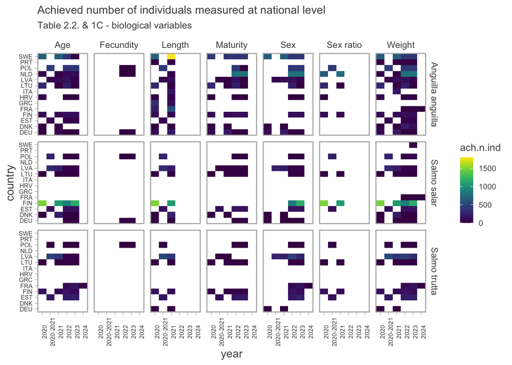

```r
diadrom.DCF.22 %>%
  rename(ach.n.ind = `Achieved number of individuals measured at national level`,
         biol.var = `Biological variable`,
         country = MS,
         year =`Implementation year`) %>%
  select(ach.n.ind, biol.var, country, year, Species) %>%
  bind_rows(diadrom.DCF.1C %>%
              rename(ach.n.ind = `Achieved number of individuals measured at the national level`,
                     biol.var = `Variables`,
                     country = MS,
                     year =`Sampling year`) %>%
              select(ach.n.ind, biol.var, country, year, Species) %>%
              mutate(biol.var = case_when(biol.var %in% c("Age","age") ~ "Age",
                                          biol.var %in% c("Length","length","lenght") ~ "Length",
                                          biol.var %in% c("Weight","weight") ~ "Weight",
                                          biol.var %in% c("Sex ratio","sex ratio") ~ "Sex ratio",
                                          biol.var %in% c("Sexual maturity","sexual maturity","maturity","Maturity") ~ "Maturity",
                                          biol.var %in% c("Sex","sex") ~ "Sex",
                                          biol.var == "NA" ~ NA,
                                          .default = biol.var))) %>%
  mutate(ach.n.ind = as.numeric(if_else(ach.n.ind == "NA", NA, ach.n.ind)),
         biol.var = as.factor(biol.var)) %>%
  drop_na(biol.var) %>%
  filter(ach.n.ind < 2000) %>%
  ggplot() +
  geom_tile(aes(year, country, fill = ach.n.ind)) +
  facet_grid(Species ~ biol.var) +
  scale_fill_viridis() +
  theme(axis.text.x = element_text(angle = 90),
        axis.text = element_text(size=6)) +
  labs(title = "Achieved number of individuals measured at national level", subtitle = "Table 2.2. & 1C - biological variables")
```

### Plot sheets 2.3 and 1E

```r
# Plot sheets 2.3 and 1E
# achieved units by Unit category needs some work and priority
c(diadrom.DCF.1E$Unit,diadrom.DCF.23$Unit) %>%
  unique() %>% length()
```

```
[1] 152
```

```r
# same with life stage
c(diadrom.DCF.1E$`Life stage`,diadrom.DCF.23$`Life stage`) %>%
  unique() %>% length()
```

```
[1] 62
```

```r
# THIS BELOW NEEDS TO BE REVISED!! FIXING CHARACTER TO NUMERICS POPERLY
diadrom.DCF.23.clean <- diadrom.DCF.23 %>%
  rename(ach.n.unit = `Achieved number of units`,
         #Diad.var = `Diadromous variable`,
         life.stage = `Life stage`,
         #unit = Unit,
         country = MS,
         year =`Implementation year`) %>%
  select(ach.n.unit, life.stage, country, year, Species) %>%
  bind_rows(diadrom.DCF.1E %>%
              rename(ach.n.unit = `Achieved numbers`,
                     #Diad.var = `Diadromous variable`,
                     life.stage = `Life stage`,
                     country = MS,
                     unit = Unit,
                     year =`Sampling period`) %>%
              select(ach.n.unit, life.stage, country, year, Species)) %>%
  mutate(life.stage = make_clean_names(life.stage, allow_dupes = TRUE),
         life.stage = case_when(life.stage %in% c("silver","silver_eel","silver_eels","silver_eel") ~ "silver",
                                life.stage %in% c("yellow_silver","yellow_silver_eel","yellow_silver","silver_eel_yellow_eel","yellow_eel_and_silver_eel", "yellow_eel_silver_eel") ~ "yellow_silver",
                                life.stage %in% c("x","na","-", "n_a","not_pertinent", "1_15", "1_year", "x1_2_y_1") ~ NA,
                                life.stage %in% c("yellow", "yellow_eel","yellow_eels", "recruits_yellow", "recruits_yellow_ss", "yellow_eel_ss") ~ "yellow",
                                life.stage %in% c("glass_eels","glass_eel","glass_eel_recruitment","recruits_glass_eel","glass_eels") ~ "glass",
                                life.stage %in% c("Sex","sex") ~ "Sex",
                                life.stage %in% c("all") ~ "All",
                                life.stage %in% c("Sex","sex") ~ "Sex",
                                life.stage %in% c("adult_spawning_salmon") ~ "spawning_adult",
                                 .default = life.stage),
         life.stage = as.factor(life.stage)) %>%
  mutate(ach.n.unit = case_when(ach.n.unit %in% c("N/A","NA","na", "not applicable","census","hundreds", " ") ~ NA,
                                .default = ach.n.unit),
         ach.n.unit.num = parse_number(ach.n.unit)) %>%
  mutate(country = if_else(country == "Spain", "ESP", country)) %>%
  drop_na(life.stage)
```

```
rename: renamed 4 variables (country, year, life.stage, ach.n.unit)
select: dropped 23 variables (Region, RFMO/RFO/IO, Management unit / River, Body of water, Species present in the MS, …)
rename: renamed 5 variables (country, year, life.stage, unit, ach.n.unit)
select: dropped 58 variables (Area, RFMO/RFO/IO, Applicable (Y/N), Reasons for not sampling, Water Body, …)
mutate: converted 'life.stage' from character to factor (111 new NA)
```

```
mutate: changed 197 values (4%) of 'ach.n.unit' (197 new NAs)
        new variable 'ach.n.unit.num' (double) with 209 unique values and 23% NA
mutate: changed 91 values (2%) of 'country' (0 new NAs)
drop_na: removed 284 rows (6%), 4,105 rows remaining
```

```
filter: removed 1,947 rows (47%), 2,158 rows remaining
```

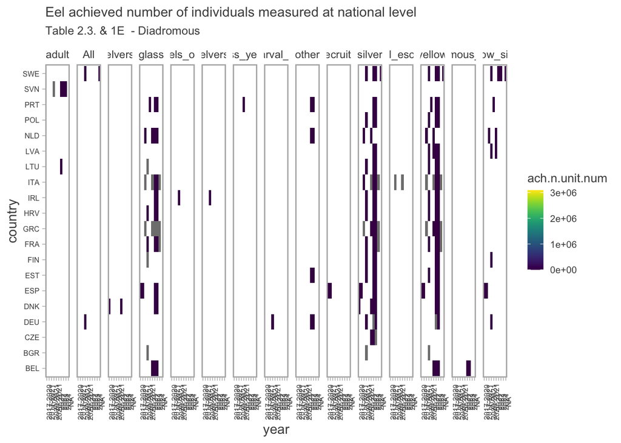

```r
diadrom.DCF.23.clean %>%
  filter(Species == "Anguilla anguilla") %>%
  ggplot() +
  geom_tile(aes(year, country, fill = ach.n.unit.num)) +
  facet_grid( ~life.stage) +
  scale_fill_viridis() +
  theme(axis.text.x = element_text(angle = 90),
        axis.text = element_text(size=6)) +
    labs(title = "Eel achieved number of individuals measured at national level", subtitle = "Table 2.3. & 1E  - Diadromous")
```

```
filter: removed 2,665 rows (65%), 1,440 rows remaining
```

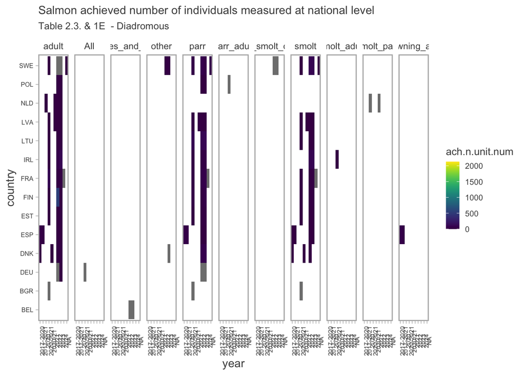

```r
# Salmon
diadrom.DCF.23.clean %>%
  filter(Species == "Salmo salar") %>%
  ggplot() +
  geom_tile(aes(year, country, fill = ach.n.unit.num)) +
  facet_grid( ~life.stage) +
  scale_fill_viridis() +
  theme(axis.text.x = element_text(angle = 90),
        axis.text = element_text(size=6)) +
    labs(title = "Salmon achieved number of individuals measured at national level", subtitle = "Table 2.3. & 1E  - Diadromous")
```

```
filter: removed 2,062 rows (50%), 2,043 rows remaining
```

[figure not shown]

```r
diadrom.DCF.23.clean %>%
  filter(life.stage %in% c("yellow", "silver", "glass", "yellow_silver")) %>%
  ggplot() +
  geom_tile(aes(year, country, fill = ach.n.unit.num)) +
  facet_grid( ~life.stage) +
  scale_fill_viridis() +
  theme(axis.text.x = element_text(angle = 90),
        axis.text = element_text(size=6)) +
    labs(title = "Salmon achieved number of individuals measured at national level", subtitle = "Table 2.3. & 1E  - Diadromous")
```